# Pokemon data analysis

## 1. Loading the modules and data

**Loading the modules**

```python
%matplotlib inline

import warnings
warnings.filterwarnings("ignore")

import pandas as pd
import seaborn as sns
import numpy as np
import matplotlib.pyplot as plt
```

**Loading the data**

```python
data=pd.read_csv('Input/Pokemon.csv')
data.shape
```

```
(800, 13)
```

```python
print(data.isnull().sum())
```

```
#               0
Name            0
Type 1          0
Type 2        386
Total           0
HP              0
Attack          0
Defense         0
Sp. Atk         0
Sp. Def         0
Speed           0
Generation      0
Legendary       0
dtype: int64
```

```python
data.head(3)
```

|  | # | Name | Type 1 | Type 2 | Total | HP | Attack | Defense | Sp. Atk | Sp. Def | Speed | Generation | Legendary |
| --- | --- | --- | --- | --- | --- | --- | --- | --- | --- | --- | --- | --- | --- |
| 0 | 1 | Bulbasaur | Grass | Poison | 318 | 45 | 49 | 49 | 65 | 65 | 45 | 1 | False |
| 1 | 2 | Ivysaur | Grass | Poison | 405 | 60 | 62 | 63 | 80 | 80 | 60 | 1 | False |
| 2 | 3 | Venusaur | Grass | Poison | 525 | 80 | 82 | 83 | 100 | 100 | 80 | 1 | False |

```python
data.sort_values('Total', ascending=False).head(5)
```

|  | # | Name | Type 1 | Type 2 | Total | HP | Attack | Defense | Sp. Atk | Sp. Def | Speed | Generation | Legendary |
| --- | --- | --- | --- | --- | --- | --- | --- | --- | --- | --- | --- | --- | --- |
| 426 | 384 | RayquazaMega Rayquaza | Dragon | Flying | 780 | 105 | 180 | 100 | 180 | 100 | 115 | 3 | True |
| 164 | 150 | MewtwoMega Mewtwo Y | Psychic | NaN | 780 | 106 | 150 | 70 | 194 | 120 | 140 | 1 | True |
| 163 | 150 | MewtwoMega Mewtwo X | Psychic | Fighting | 780 | 106 | 190 | 100 | 154 | 100 | 130 | 1 | True |
| 422 | 382 | KyogrePrimal Kyogre | Water | NaN | 770 | 100 | 150 | 90 | 180 | 160 | 90 | 3 | True |
| 424 | 383 | GroudonPrimal Groudon | Ground | Fire | 770 | 100 | 180 | 160 | 150 | 90 | 90 | 3 | True |

The best pokemon with overall rating is *RayquazaMega Rayquaza*, *MewtwoMega Mewtwo Y* and *MewtwoMega Mewtwo X*.

```python
data.sort_values('Attack', ascending=False).head(5)
```

|  | # | Name | Type 1 | Type 2 | Total | HP | Attack | Defense | Sp. Atk | Sp. Def | Speed | Generation | Legendary |
| --- | --- | --- | --- | --- | --- | --- | --- | --- | --- | --- | --- | --- | --- |
| 163 | 150 | MewtwoMega Mewtwo X | Psychic | Fighting | 780 | 106 | 190 | 100 | 154 | 100 | 130 | 1 | True |
| 232 | 214 | HeracrossMega Heracross | Bug | Fighting | 600 | 80 | 185 | 115 | 40 | 105 | 75 | 2 | False |
| 424 | 383 | GroudonPrimal Groudon | Ground | Fire | 770 | 100 | 180 | 160 | 150 | 90 | 90 | 3 | True |
| 426 | 384 | RayquazaMega Rayquaza | Dragon | Flying | 780 | 105 | 180 | 100 | 180 | 100 | 115 | 3 | True |
| 429 | 386 | DeoxysAttack Forme | Psychic | NaN | 600 | 50 | 180 | 20 | 180 | 20 | 150 | 3 | True |

The best pokemon for attack is *MewtwoMega Mewtwo X*.

```python
data.sort_values('Defense', ascending=False).head(5)
```

|  | # | Name | Type 1 | Type 2 | Total | HP | Attack | Defense | Sp. Atk | Sp. Def | Speed | Generation | Legendary |
| --- | --- | --- | --- | --- | --- | --- | --- | --- | --- | --- | --- | --- | --- |
| 230 | 213 | Shuckle | Bug | Rock | 505 | 20 | 10 | 230 | 10 | 230 | 5 | 2 | False |
| 224 | 208 | SteelixMega Steelix | Steel | Ground | 610 | 75 | 125 | 230 | 55 | 95 | 30 | 2 | False |
| 333 | 306 | AggronMega Aggron | Steel | NaN | 630 | 70 | 140 | 230 | 60 | 80 | 50 | 3 | False |
| 223 | 208 | Steelix | Steel | Ground | 510 | 75 | 85 | 200 | 55 | 65 | 30 | 2 | False |
| 414 | 377 | Regirock | Rock | NaN | 580 | 80 | 100 | 200 | 50 | 100 | 50 | 3 | True |

```python
data[data['Legendary']==True].sort_values('Total', ascending=False).head(10)
```

|  | # | Name | Type 1 | Type 2 | Total | HP | Attack | Defense | Sp. Atk | Sp. Def | Speed | Generation | Legendary |
| --- | --- | --- | --- | --- | --- | --- | --- | --- | --- | --- | --- | --- | --- |
| 163 | 150 | MewtwoMega Mewtwo X | Psychic | Fighting | 780 | 106 | 190 | 100 | 154 | 100 | 130 | 1 | True |
| 164 | 150 | MewtwoMega Mewtwo Y | Psychic | NaN | 780 | 106 | 150 | 70 | 194 | 120 | 140 | 1 | True |
| 426 | 384 | RayquazaMega Rayquaza | Dragon | Flying | 780 | 105 | 180 | 100 | 180 | 100 | 115 | 3 | True |
| 422 | 382 | KyogrePrimal Kyogre | Water | NaN | 770 | 100 | 150 | 90 | 180 | 160 | 90 | 3 | True |
| 424 | 383 | GroudonPrimal Groudon | Ground | Fire | 770 | 100 | 180 | 160 | 150 | 90 | 90 | 3 | True |
| 552 | 493 | Arceus | Normal | NaN | 720 | 120 | 120 | 120 | 120 | 120 | 120 | 4 | True |
| 711 | 646 | KyuremBlack Kyurem | Dragon | Ice | 700 | 125 | 170 | 100 | 120 | 90 | 95 | 5 | True |
| 418 | 380 | LatiasMega Latias | Dragon | Psychic | 700 | 80 | 100 | 120 | 140 | 150 | 110 | 3 | True |
| 712 | 646 | KyuremWhite Kyurem | Dragon | Ice | 700 | 125 | 120 | 90 | 170 | 100 | 95 | 5 | True |
| 796 | 719 | DiancieMega Diancie | Rock | Fairy | 700 | 50 | 160 | 110 | 160 | 110 | 110 | 6 | True |

So the legendary pokemon are extremely powerfull than non-legendary pokemon.

```python
data[data['Legendary']==False].sort_values('Total', ascending=False).head(10)
```

|  | # | Name | Type 1 | Type 2 | Total | HP | Attack | Defense | Sp. Atk | Sp. Def | Speed | Generation | Legendary |
| --- | --- | --- | --- | --- | --- | --- | --- | --- | --- | --- | --- | --- | --- |
| 413 | 376 | MetagrossMega Metagross | Steel | Psychic | 700 | 80 | 145 | 150 | 105 | 110 | 110 | 3 | False |
| 494 | 445 | GarchompMega Garchomp | Dragon | Ground | 700 | 108 | 170 | 115 | 120 | 95 | 92 | 4 | False |
| 409 | 373 | SalamenceMega Salamence | Dragon | Flying | 700 | 95 | 145 | 130 | 120 | 90 | 120 | 3 | False |
| 268 | 248 | TyranitarMega Tyranitar | Rock | Dark | 700 | 100 | 164 | 150 | 95 | 120 | 71 | 2 | False |
| 313 | 289 | Slaking | Normal | NaN | 670 | 150 | 160 | 100 | 95 | 65 | 100 | 3 | False |
| 141 | 130 | GyaradosMega Gyarados | Water | Dark | 640 | 95 | 155 | 109 | 70 | 130 | 81 | 1 | False |
| 283 | 260 | SwampertMega Swampert | Water | Ground | 635 | 100 | 150 | 110 | 95 | 110 | 70 | 3 | False |
| 8 | 6 | CharizardMega Charizard Y | Fire | Flying | 634 | 78 | 104 | 78 | 159 | 115 | 100 | 1 | False |
| 7 | 6 | CharizardMega Charizard X | Fire | Dragon | 634 | 78 | 130 | 111 | 130 | 85 | 100 | 1 | False |
| 12 | 9 | BlastoiseMega Blastoise | Water | NaN | 630 | 79 | 103 | 120 | 135 | 115 | 78 | 1 | False |

```python
data[data['Legendary']==False].sort_values('Total', ascending=False).drop_duplicates(subset=['Generation'], keep='first').sort_values('Generation')[['Name', 'Generation', 'Total']]
```

|  | Name | Generation | Total |
| --- | --- | --- | --- |
| 141 | GyaradosMega Gyarados | 1 | 640 |
| 268 | TyranitarMega Tyranitar | 2 | 700 |
| 413 | MetagrossMega Metagross | 3 | 700 |
| 494 | GarchompMega Garchomp | 4 | 700 |
| 716 | MeloettaPirouette Forme | 5 | 600 |
| 776 | Goodra | 6 | 600 |

The above table shows the best non-legendary pokemon across various generations.

```python
data[data['Legendary']==True].sort_values('Total', ascending=False).drop_duplicates(subset=['Generation'], keep='first').sort_values('Generation')[['Name', 'Generation', 'Total']]
```

|  | Name | Generation | Total |
| --- | --- | --- | --- |
| 163 | MewtwoMega Mewtwo X | 1 | 780 |
| 270 | Ho-oh | 2 | 680 |
| 426 | RayquazaMega Rayquaza | 3 | 780 |
| 552 | Arceus | 4 | 720 |
| 711 | KyuremBlack Kyurem | 5 | 700 |
| 796 | DiancieMega Diancie | 6 | 700 |

The above table shows the best legendary pokemon across various generations.

```python
data.sort_values('Total').drop_duplicates(subset=['Type 1'], keep='last')[['Name', 'Type 1', 'Total']]
```

|  | Name | Type 1 | Total |
| --- | --- | --- | --- |
| 183 | Crobat | Poison | 535 |
| 702 | TornadusIncarnate Forme | Flying | 580 |
| 156 | Articuno | Ice | 580 |
| 137 | PinsirMega Pinsir | Bug | 600 |
| 196 | AmpharosMega Ampharos | Electric | 610 |
| 498 | LucarioMega Lucario | Fighting | 625 |
| 275 | SceptileMega Sceptile | Grass | 630 |
| 793 | Yveltal | Dark | 680 |
| 792 | Xerneas | Fairy | 680 |
| 270 | Ho-oh | Fire | 680 |
| 544 | GiratinaAltered Forme | Ghost | 680 |
| 796 | DiancieMega Diancie | Rock | 700 |
| 413 | MetagrossMega Metagross | Steel | 700 |
| 552 | Arceus | Normal | 720 |
| 424 | GroudonPrimal Groudon | Ground | 770 |
| 422 | KyogrePrimal Kyogre | Water | 770 |
| 426 | RayquazaMega Rayquaza | Dragon | 780 |
| 163 | MewtwoMega Mewtwo X | Psychic | 780 |

The above table shows the best pokemon different primary skill.

```python
data.sort_values('Total').drop_duplicates(subset=['Type 2'], keep='last').dropna()[['Name', 'Type 2', 'Total']]
```

|  | Name | Type 2 | Total |
| --- | --- | --- | --- |
| 380 | Armaldo | Bug | 495 |
| 736 | Pyroar | Normal | 507 |
| 515 | Rhyperior | Rock | 535 |
| 797 | HoopaHoopa Confined | Ghost | 600 |
| 271 | Celebi | Grass | 600 |
| 799 | Volcanion | Water | 600 |
| 3 | VenusaurMega Venusaur | Poison | 625 |
| 498 | LucarioMega Lucario | Steel | 625 |
| 707 | Zekrom | Electric | 680 |
| 544 | GiratinaAltered Forme | Dragon | 680 |
| 268 | TyranitarMega Tyranitar | Dark | 700 |
| 796 | DiancieMega Diancie | Fairy | 700 |
| 413 | MetagrossMega Metagross | Psychic | 700 |
| 494 | GarchompMega Garchomp | Ground | 700 |
| 712 | KyuremWhite Kyurem | Ice | 700 |
| 424 | GroudonPrimal Groudon | Fire | 770 |
| 426 | RayquazaMega Rayquaza | Flying | 780 |
| 163 | MewtwoMega Mewtwo X | Fighting | 780 |

The above table shows the best pokemon different secondary skill.

```python
data.sort_values('Attack').drop_duplicates(subset=['Type 1'], keep='last')[['Name', 'Type 1', 'Attack']]
```

|  | Name | Type 1 | Attack |
| --- | --- | --- | --- |
| 504 | Toxicroak | Poison | 106 |
| 702 | TornadusIncarnate Forme | Flying | 115 |
| 517 | Electivire | Electric | 123 |
| 524 | Mamoswine | Ice | 130 |
| 792 | Xerneas | Fairy | 131 |
| 511 | AbomasnowMega Abomasnow | Grass | 132 |
| 498 | LucarioMega Lucario | Fighting | 145 |
| 393 | AbsolMega Absol | Dark | 150 |
| 750 | AegislashBlade Forme | Steel | 150 |
| 141 | GyaradosMega Gyarados | Water | 155 |
| 279 | BlazikenMega Blaziken | Fire | 160 |
| 313 | Slaking | Normal | 160 |
| 387 | BanetteMega Banette | Ghost | 165 |
| 454 | Rampardos | Rock | 165 |
| 426 | RayquazaMega Rayquaza | Dragon | 180 |
| 424 | GroudonPrimal Groudon | Ground | 180 |
| 232 | HeracrossMega Heracross | Bug | 185 |
| 163 | MewtwoMega Mewtwo X | Psychic | 190 |

The above table shows the best attacking pokemon among different skill set.

```python
data.sort_values('Defense').drop_duplicates(subset=['Type 1'], keep='last')[['Name', 'Type 1', 'Defense']]
```

|  | Name | Type 1 | Defense |
| --- | --- | --- | --- |
| 791 | Noivern | Flying | 80 |
| 256 | Hitmontop | Fighting | 95 |
| 519 | Togekiss | Fairy | 95 |
| 513 | Magnezone | Electric | 115 |
| 118 | Weezing | Poison | 120 |
| 327 | SableyeMega Sableye | Dark | 125 |
| 591 | AudinoMega Audino | Normal | 126 |
| 409 | SalamenceMega Salamence | Dragon | 130 |
| 659 | Ferrothorn | Grass | 131 |
| 355 | Torkoal | Fire | 140 |
| 624 | Cofagrigus | Ghost | 145 |
| 424 | GroudonPrimal Groudon | Ground | 160 |
| 430 | DeoxysDefense Forme | Psychic | 160 |
| 87 | SlowbroMega Slowbro | Water | 180 |
| 789 | Avalugg | Ice | 184 |
| 414 | Regirock | Rock | 200 |
| 230 | Shuckle | Bug | 230 |
| 224 | SteelixMega Steelix | Steel | 230 |

The above table shows the best defensive pokemon among different skill set.

```python
data.sort_values('HP').drop_duplicates(subset=['Type 1'], keep='last')[['Name', 'Type 1', 'HP']]
```

|  | Name | Type 1 | HP |
| --- | --- | --- | --- |
| 791 | Noivern | Flying | 85 |
| 520 | Yanmega | Bug | 86 |
| 262 | Raikou | Electric | 90 |
| 540 | Dialga | Steel | 100 |
| 96 | Muk | Poison | 105 |
| 400 | Walrein | Ice | 110 |
| 515 | Rhyperior | Ground | 115 |
| 263 | Entei | Fire | 115 |
| 741 | Gogoat | Grass | 123 |
| 769 | Aurorus | Rock | 123 |
| 712 | KyuremWhite Kyurem | Dragon | 125 |
| 793 | Yveltal | Dark | 126 |
| 792 | Xerneas | Fairy | 126 |
| 321 | Hariyama | Fighting | 144 |
| 473 | Drifblim | Ghost | 150 |
| 351 | Wailord | Water | 170 |
| 217 | Wobbuffet | Psychic | 190 |
| 261 | Blissey | Normal | 255 |

The above table shows the pokemons with best *HP* among different skills.

```python
data.sort_values('Speed', ascending=False)[['Name', 'Speed']].head()
```

|  | Name | Speed |
| --- | --- | --- |
| 431 | DeoxysSpeed Forme | 180 |
| 315 | Ninjask | 160 |
| 428 | DeoxysNormal Forme | 150 |
| 154 | AerodactylMega Aerodactyl | 150 |
| 71 | AlakazamMega Alakazam | 150 |

So the pokemon with greatest speed in *DeoxysSpeed Forme*.

```python
data['A+D']=data['Attack']+data['Sp. Atk']+data['Defense']+data['Sp. Def']
data.sort_values('A+D', ascending=False)[['Name', 'A+D']].head()
```

|  | Name | A+D |
| --- | --- | --- |
| 422 | KyogrePrimal Kyogre | 580 |
| 424 | GroudonPrimal Groudon | 580 |
| 426 | RayquazaMega Rayquaza | 560 |
| 163 | MewtwoMega Mewtwo X | 544 |
| 796 | DiancieMega Diancie | 540 |

So the pokemons with best attack and defense are *KyogrePrimal Kyogre* and *GroudonPrimal Groudon*.

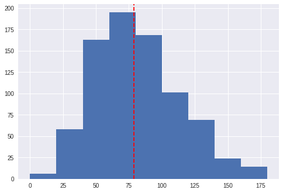

```python
plt.hist(data['Attack'], bins=range(0, 200, 20), histtype='bar',)
plt.axvline(data['Attack'].mean(),linestyle='dashed',color='red')
```

The mean attack of the pokemon is around 80.

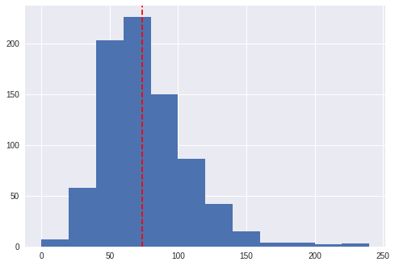

```python
plt.hist(data['Defense'], bins=range(0, 250, 20), histtype='bar',)
plt.axvline(data['Defense'].mean(),linestyle='dashed',color='red')
```

The mean defense of the pokemon is around 75.

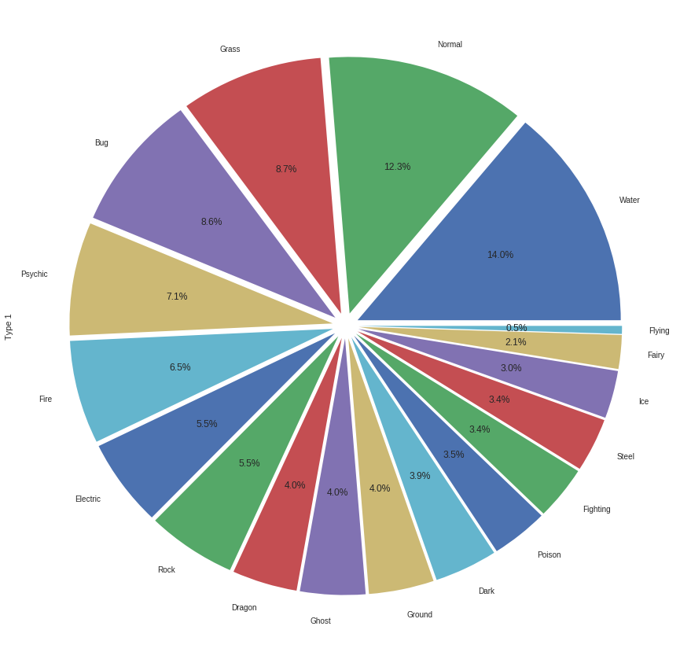

```python
explode=[]
for i in range(len(data['Type 1'].unique())):
    explode.append(0.05)
data['Type 1'].value_counts().plot(kind='pie', explode=explode, autopct='%1.1f%%')
fig=plt.gcf()
fig.set_size_inches(15, 15)
plt.show()
```

```python
df=data.drop(['#', 'Generation', 'Legendary', 'Total', 'A+D'], axis=1)
```

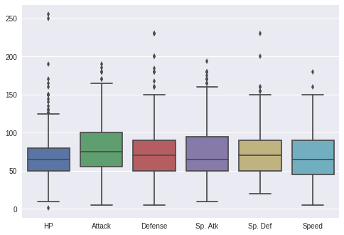

```python
sns.boxplot(df)
```

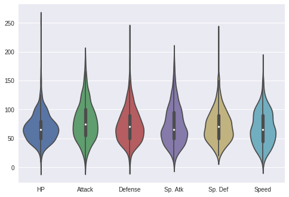

```python
sns.violinplot(data=df)
```

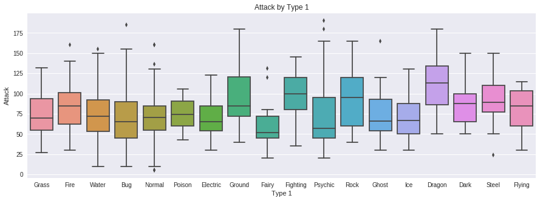

```python
plt.figure(figsize=(15,5))
plt.title('Attack by Type 1')
sns.boxplot(x='Type 1', y='Attack', data=data)
```

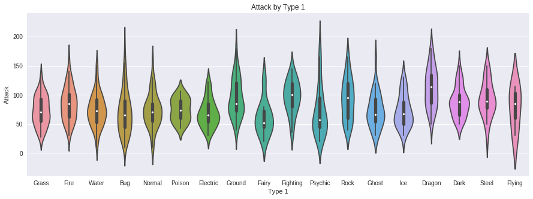

```python
plt.figure(figsize=(15,5))
plt.title('Attack by Type 1')
sns.violinplot(x='Type 1', y='Attack', data=data)
```

The dragon pokemons have more stronger attacking capabilites than other types.

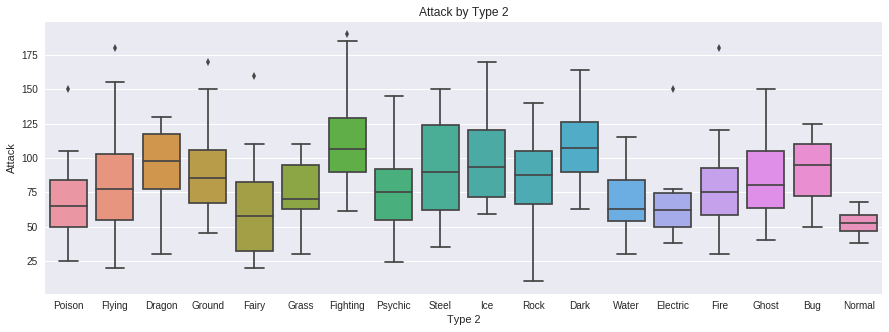

```python
plt.figure(figsize=(15,5))
plt.title('Attack by Type 2')
sns.boxplot(x='Type 2', y='Attack', data=data)
```

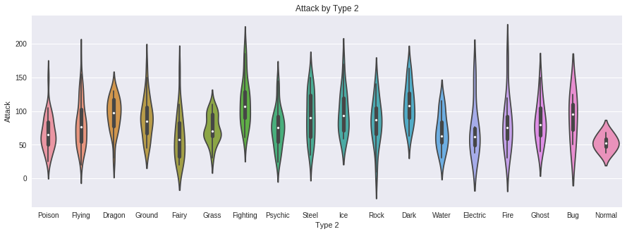

```python
plt.figure(figsize=(15,5))
plt.title('Attack by Type 2')
sns.violinplot(x='Type 2', y='Attack', data=data)
```

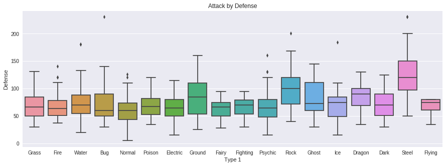

```python
plt.figure(figsize=(15,5))
plt.title('Attack by Defense')
sns.boxplot(x='Type 1', y='Defense', data=data)
```

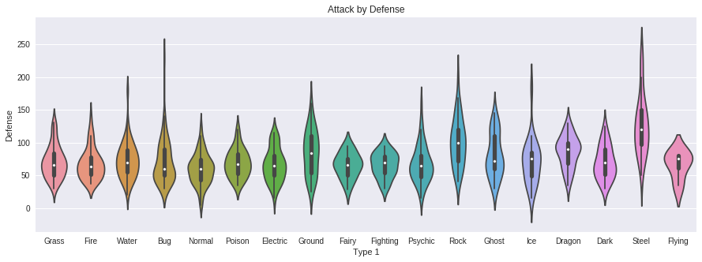

```python
plt.figure(figsize=(15,5))
plt.title('Attack by Defense')
sns.violinplot(x='Type 1', y='Defense', data=data)
```

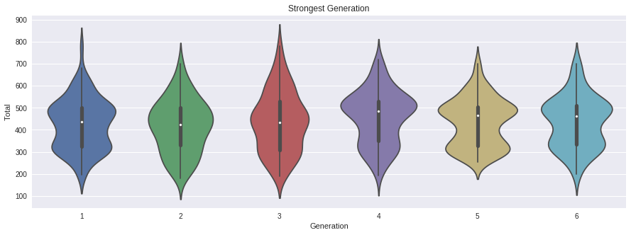

```python
plt.figure(figsize=(15,5))
plt.title('Strongest Generation')
sns.violinplot(x='Generation', y='Total', data=data)
```

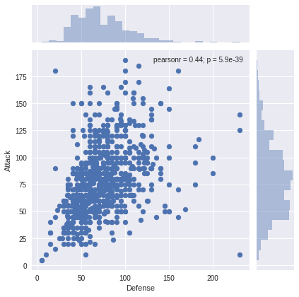

```python
sns.jointplot(x="Defense", y="Attack", data=data)
```

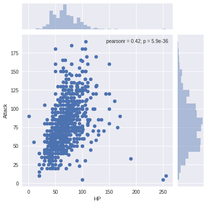

```python
sns.jointplot(x="HP", y="Attack", data=data)
```

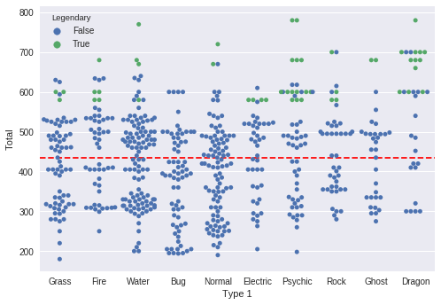

```python
top_types=data['Type 1'].value_counts().head(10).reset_index()
df=data[data['Type 1'].isin(top_types['index'])]
sns.swarmplot(x='Type 1', y='Total', data=df, hue='Legendary')
plt.axhline(df['Total'].mean(),color='red',linestyle='dashed')
plt.show()
```

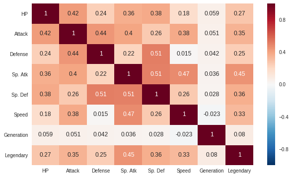

```python
df=data.drop(['#', 'Total', 'A+D'], axis=1)

plt.figure(figsize=(10,6))
sns.heatmap(df.corr(),annot=True)
plt.show()
```